# Generative Art

Author

Aditi Gajjar

## **Bloom - ordinary plotting functions**

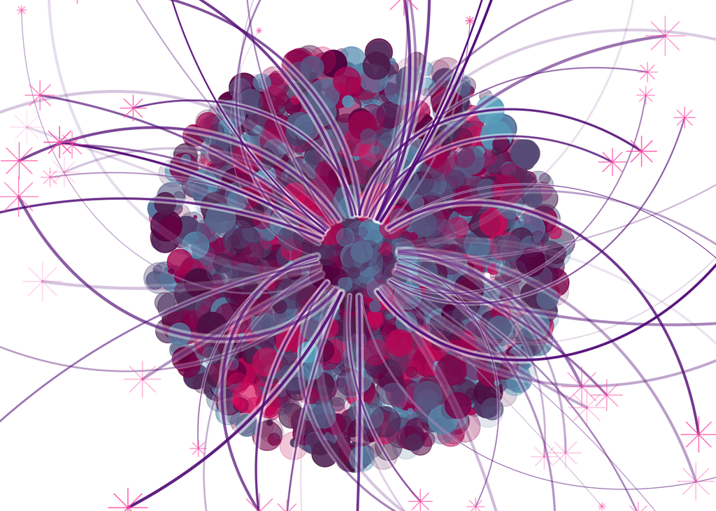

**Description:** Inspired by limited Spring flavor of GT Kombucha: Bloom, this art showcases the feeling I get every time this year when this flavor is released for the short period of time. I believe it lives up to its name, making me feel one with the flowers, and nothing short of whimsical. The artwork above, titled Bloom, encompasses that.

## **Barbie Birkin - completely generative**

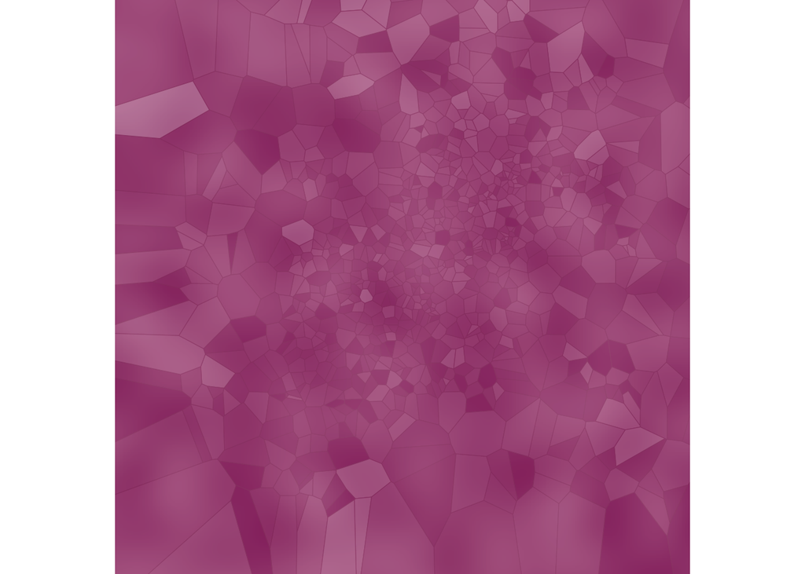

**Description:** This is what I would assume that a Barbie Birkin would look like up close. Not to say I have seen a Birkin up close (or from afar if I am being honest), however, this is what I assume it would look like. Upon rendering this image I am happy to report that I am not enticed by th idea of owning a Birkin, as even the color pink does not appeal me to this monstrosity.

**Code Choices:**

- Outside of choosing colors, I combined two packages to create a sort of tiled texture design. I first used the ambient package to create that noise and diffused color look that I overlayed with tiles that I got from the voronoise package. I played around wiht the number of tiles, and the length of the noise until iIgot a pattern that was stark and interesting enough to capture my vision: 500 data points.